# Predicting the quality of lifting exercises using accelerometer data.

The developement of cheap accelerometer has allowed scientist to efficently record accerelations of bodyparts while doing exercise. The aim of this project is to predict if a person is doing dumbell weight lifting correctly usinga number of recorded movement variables. The data used in this study comes from reference [1], and comprises 19622 observations from accelerometers on the belt, forearm, arm, and dumbell of participants doing dumbell weight lifting in five different manners. In the study, we will try to predict the manner in which the excercise was done given the accelerometer data.

### Data loading and pre-processing

Loading useful libraries

```r
library(caret)
library(randomForest)
data<-read.csv('pml-training.csv',row.names=1)
data[data==""]<-NA
t<-sapply(data, function(x) sum(is.na(x)) < 10000)
dataClean<-data[sapply(data, function(x) sum(is.na(x)) < 10000)]
dataClean<-dataClean[,c(-1,-2,-3,-4,-5,-6)]
```

All empty values were replaced by NAs and columns with more than 10000 NAs were removed from the datasets. Furthermore, username, timestamps and window information were also removed from the dataset.

```r
testIndex<-createDataPartition(dataClean$classe,p=0.4,list=FALSE)
training<-dataClean[-testIndex,]
testing<-dataClean[testIndex,]
```

The data is split in a training set (60%) and a test set (40%).

In the training set, each classe of excersize quality is well represented which should allow for the training of an algorithm to predict the quality of the excersize based accelerometer data.

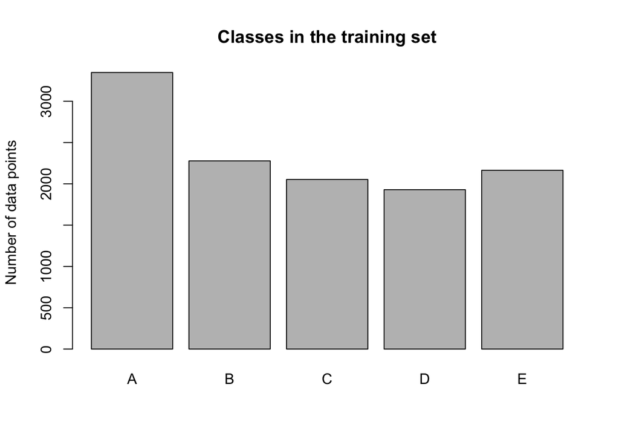

```r
barplot(table(training$classe),main="Classes in the training set",ylab="Number of data points")
```

### Prediction model

The cross-validation used for the training is the default bootstrapping method.

```r
preProc<-preProcess(training[,-53],method="pca",thresh=.9)
trainingC<-predict(preProc,training[,-53])

set.seed(1234)
modelFit<-train(training$classe ~ . ,method="rf",data=trainingC)
modelFit
```

```
## Random Forest
##
## 11772 samples
##    19 predictor
##     5 classes: 'A', 'B', 'C', 'D', 'E'
##
## No pre-processing
## Resampling: Bootstrapped (25 reps)
##
## Summary of sample sizes: 11772, 11772, 11772, 11772, 11772, 11772, ...
##
## Resampling results across tuning parameters:
##
##   mtry  Accuracy  Kappa  Accuracy SD  Kappa SD
##    2    1.0       0.9    0.004        0.005
##   11    0.9       0.9    0.004        0.005
##   20    0.9       0.9    0.007        0.009
##
## Accuracy was used to select the optimal model using  the largest value.
## The final value used for the model was mtry = 2.
```

### Prediction errors.

In sample error was estimated to make sure no bias was present in the training set.

```r
trainPred<-predict(modelFit,trainingC);
confusionMatrix(trainPred, training$classe)
```

```
## Confusion Matrix and Statistics
##
##           Reference
## Prediction    A    B    C    D    E
##          A 3348    0    0    0    0
##          B    0 2278    0    0    0
##          C    0    0 2053    0    0
##          D    0    0    0 1929    0
##          E    0    0    0    0 2164
##
## Overall Statistics
##
##                Accuracy : 1
##                  95% CI : (1, 1)
##     No Information Rate : 0.284
##     P-Value [Acc > NIR] : <2e-16
##
##                   Kappa : 1
##  Mcnemar's Test P-Value : NA
##
## Statistics by Class:
##
##                      Class: A Class: B Class: C Class: D Class: E
## Sensitivity             1.000    1.000    1.000    1.000    1.000
## Specificity             1.000    1.000    1.000    1.000    1.000
## Pos Pred Value          1.000    1.000    1.000    1.000    1.000
## Neg Pred Value          1.000    1.000    1.000    1.000    1.000
## Prevalence              0.284    0.194    0.174    0.164    0.184
## Detection Rate          0.284    0.194    0.174    0.164    0.184
## Detection Prevalence    0.284    0.194    0.174    0.164    0.184
## Balanced Accuracy       1.000    1.000    1.000    1.000    1.000
```

The accuracy of the model on the training set is 100%, so there is no bias problem but our model maybe overfits the data.

Out of sample error was calculated by using the model to predict the classe for the values of the cross-validation set.

```r
testingC<-predict(preProc,testing[,-53])
testPred<-predict(modelFit,testingC)
confusionMatrix(testPred, testing$classe)
```

```
## Confusion Matrix and Statistics
##
##           Reference
## Prediction    A    B    C    D    E
##          A 2227    8    5    0    1
##          B    3 1498   11    0    7
##          C    0    9 1349   24    3
##          D    1    3    2 1261    4
##          E    1    1    2    2 1428
##
## Overall Statistics
##
##                Accuracy : 0.989
##                  95% CI : (0.986, 0.991)
##     No Information Rate : 0.284
##     P-Value [Acc > NIR] : < 2e-16
##
##                   Kappa : 0.986
##  Mcnemar's Test P-Value : 0.000104
##
## Statistics by Class:
##
##                      Class: A Class: B Class: C Class: D Class: E
## Sensitivity             0.998    0.986    0.985    0.980    0.990
## Specificity             0.998    0.997    0.994    0.998    0.999
## Pos Pred Value          0.994    0.986    0.974    0.992    0.996
## Neg Pred Value          0.999    0.997    0.997    0.996    0.998
## Prevalence              0.284    0.194    0.174    0.164    0.184
## Detection Rate          0.284    0.191    0.172    0.161    0.182
## Detection Prevalence    0.285    0.194    0.176    0.162    0.183
## Balanced Accuracy       0.998    0.991    0.990    0.989    0.994
```

The model has an accuracy of around 99% on cross-validation test. This was deemed sufficient to predict the values of the classe for the test set.

### Prediction on the test set

The model was then use to predict the classe of the weight lifting exersize for 20 data points.

```r
dataTest<-read.csv('pml-testing.csv',row.names=1)
dataTest<-dataTest[t]
dataTest<-dataTest[,c(-1,-2,-3,-4,-5,-6)]
dataTestC<-predict(preProc,dataTest[,-53])
pred<-predict(modelFit,dataTestC)
pred
```

```
##  [1] B A B A A E D B A A B C B A E E A B B B
## Levels: A B C D E
```

### References

[1] Velloso, E.; Bulling, A.; Gellersen, H.; Ugulino, W.; Fuks, H. Qualitative Activity Recognition of Weight Lifting Exercises. Proceedings of 4th International Conference in Cooperation with SIGCHI (Augmented Human ’13) . Stuttgart, Germany: ACM SIGCHI, 2013.